# Homework on SVMs and Spectral Clustering

## Victoria Anguix López - 100516919

## Pamela Carolina Díaz Serrano - 100428899

*Machine Learning II. Master in Big Data Analytics*

*Emilio Parrado Hernández eparrado@ing.uc3m.es*

```python
import numpy as np
import matplotlib.pyplot as plt
import pandas as pd
from sklearn import svm
from sklearn.metrics import accuracy_score

from sklearn.cluster import SpectralClustering
from sklearn.metrics import accuracy_score
```

# Introduction

The key to the success of a supervised learning algorithm is the number and quality of the labels. Collecting labelled examples can be costly and difficult in some applications. In this assignment you will simulate an scenario in which labels are scarce. You will study the impact of the number of available labels in the results and explore a strategy to try to achieve good results with a reduced number of labelled examples.

You will work with the MNIST data that we used in the SVM lab session. We have prepared two binary problems of different nature with these data.

You can use the values for the SVM parameters `C=100` and `gamma=0.001` found in that corresponding lab session.

# 1. SVM with randomly selected labels

The first result is to analize the changes in performance of the SVM as the number of available labelled examples increases. The data for the first problem that you will study is in files "x_01.csv" and "y_01.csv". This problem consists in to separate 0s from 1s.

The code in the following cell loads these data and plots some of the examples.

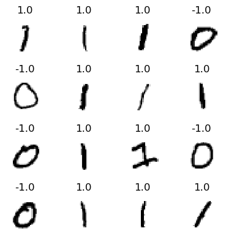

```python
Y = np.loadtxt("y_01.csv",
                       delimiter=",")
X = np.loadtxt("x_01.csv",
                       delimiter=",")

nrows = 4
ncols = 4
ff,aa = plt.subplots(nrows, ncols,figsize=(4,4))
ii = 0
for rr in range(nrows):
    for cc in range(ncols):
        aa[rr][cc].set_axis_off()
        aa[rr][cc].imshow(X[ii].reshape(28,28),
                          cmap=plt.cm.gray_r,
                          interpolation='nearest')
        aa[rr][cc].set_title(repr(Y[ii]))
        ii += 1
ff.tight_layout()
```

It seems a reasonably easy classification in terms of the separability of the classes. Therefore, it should be easy to achieve good classification results with a training dataset of relative small size.

You are now analizing how the results of the SVM improve as you get more and more labelled data. In the next cell implement python code that peforms the following functionalities.

- Run a `for` loop for all the values in the np.array `v_num_labels`. Let's say in iteration `nn` of the loop `num_data = v_num_labels[nn]`
  - construct a training set of `num_data` observations by sampling at random `num_data` rows of `X` and the corresponding elements of `Y` as true labels. In this iteration of the loop you are simulating you only have labels for these `num_data` observations, therefore you can only use these observations to fit the SVM.
  - train a SVM with this training subset of size `num_data`
  - evaluate this SVM with `X` and `Y` and store the result in the position `nn` of `acc_svm_random_label`. Here you are using the whole dataset, but just for evaluation and reporting purposes, not for fitting the model.
- Plot `acc_svm_random_label` vs `v_num_labels` and discuss the impact of the number of available labelled examples in the classification accuracy

**Note**

It could happen that, specially for the smallest values of `v_num_lables`, all the `ll` samples belong to the same class. In that case store a $0.5$ in the corresponding position of `acc_svm_random_label` since you would think all the observations belong to a same class and therefore only half of the observations in `X` will get a correct classification.

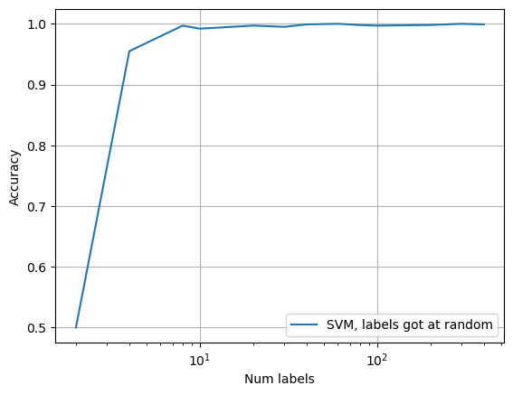

```python
# Load data
X = pd.read_csv('x_01.csv').to_numpy()
Y = pd.read_csv('y_01.csv').to_numpy().ravel()

# Define parameters
C = 100
gamma = 0.001

# Define the number of labelled samples
v_num_labels = np.array([2, 4, 8, 10, 20, 30, 40, 60, 80, 100, 200, 300, 400])

# Initialize array to store accuracy values (for each iteration varying the number of labels)
acc_svm_random_label = np.empty(len(v_num_labels))

# Loop through different numbers of labelled samples
for nn, num_data in enumerate(v_num_labels):
    # Randomly select num_data training examples
    idx = np.random.choice(len(X), size=num_data, replace=False)
    X_train = X[idx] #we create a train set with the randomly selected labels
    Y_train = Y[idx]

    # Check if both classes are present in the sampled data
    unique_classes = np.unique(Y_train)
    if len(unique_classes) < 2:
        acc_svm_random_label[nn] = 0.5  # Set accuracy to 0.5 for random guessing
    else:
        # Train SVM with the selected training examples
        clf = svm.SVC(kernel='rbf', C=C, gamma=gamma)
        clf.fit(X_train, Y_train)

        # Evaluate the SVM using the entire dataset
        accuracy = clf.score(X, Y)
        acc_svm_random_label[nn] = accuracy

# Plot accuracy vs number of labels
plt.figure()
plt.plot(v_num_labels, acc_svm_random_label, label='SVM, labels got at random')
plt.legend()
plt.xlabel('Num labels')
plt.ylabel('Accuracy')
plt.xscale('log')
plt.grid()
plt.show()
```

The plot above shows the relationship between the number of labeled samples used for training an SVM model and the resulting classification accuracy. The x-axis is on a logarithmic scale and represents the number of labeled samples, while the y-axis represents the accuracy of the classifier.

From the plot, it seems that with a very small number of labels (less than 10), the accuracy quickly increases. This suggests that even a small number of labeled examples can be quite informative for the SVM when distinguishing between the digits 0 and 1 in the MNIST dataset. Given that these two digits are quite distinct in terms of their shapes, it is possible for an SVM to achieve reasonable separation with few examples.

Beyond 10 labels, the improvement in accuracy starts to plateau, reaching close to 1.0. This indicates that adding more labeled examples yields diminishing returns in terms of accuracy gains. It is likely that the SVM has already found a decision boundary that generalizes well to the entire dataset, and additional data does not significantly alter this boundary. The initial steep improvement and subsequent plateau is a common pattern in learning curves. It reflects that initially, every new example can significantly improve the model's understanding of the decision boundary. However, once the model has 'learned' enough about the data, new examples only provide incremental improvements, as the model is already performing well.

The fact that the model achieves near-perfect accuracy indicates that the SVM is a suitable model for this task with our data and that the digits 0 and 1 are linearly separable to a high degree in the feature space defined by the pixel values when using an RBF kernel with the specified C and gamma parameters.

To get a more robust statistical significance of the results, in the next cell run the above loop a number of `NSIM` times, storing the results in the 2D array `acc_svm_random_label`. Then plot the mean of `acc_svm_random_label` and one standard deviation

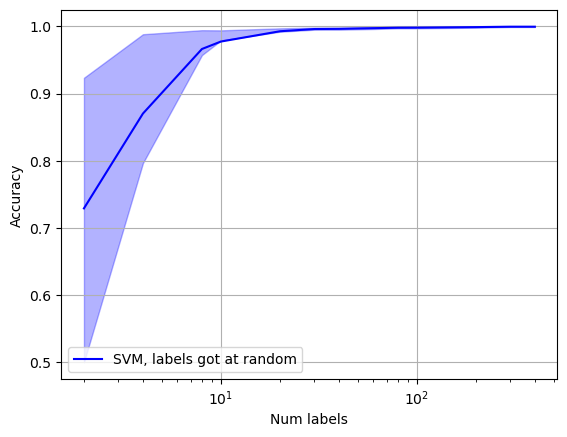

```python
NSIM = 100
acc_svm_random_label = np.empty((NSIM, len(v_num_labels)))  # each row is for each of the NSIM simulations

# Loop through different simulations
for sim in range(NSIM):
    # Loop through different numbers of labelled samples (same loop as before)
    for nn, num_data in enumerate(v_num_labels):
        # Randomly select num_data training examples
        idx = np.random.choice(len(X), size=num_data, replace=False)
        X_train = X[idx]
        Y_train = Y[idx]

        # Check if both classes are present in the sampled data
        unique_classes = np.unique(Y_train)
        if len(unique_classes) < 2:
            acc_svm_random_label[sim, nn] = 0.5  # Set accuracy to 0.5 for random guessing
        else:
            # Train SVM with the selected training examples
            clf = svm.SVC(kernel='rbf', C=C, gamma=gamma)
            clf.fit(X_train, Y_train)

            # Evaluate the SVM using the entire dataset
            accuracy = clf.score(X, Y)
            acc_svm_random_label[sim, nn] = accuracy

# Plot
plt.figure()
plt.plot(v_num_labels, np.mean(acc_svm_random_label, axis=0), label='SVM, labels got at random', color='blue')
plt.fill_between(v_num_labels, np.percentile(acc_svm_random_label, 25, axis=0),
                 np.percentile(acc_svm_random_label, 75, axis=0),
                 color='blue', alpha=0.3)
plt.legend()
plt.xlabel('Num labels')
plt.ylabel('Accuracy')
plt.xscale('log')
plt.grid()
plt.show()
```

As an important remark, notice that we have decided to plot the percentiles instead of the standard deviation because standard deviation might imply that the data is symmetrically distributed around the mean, when in fact, the accuracy could be skewed or have outliers, especially with small numbers of labels. On the other hand, the percentiles show the central bulk of the distribution without such assumptions, offering a more accurate picture if the data is not normally distributed.

The plot shows the mean accuracy of the SVM classifier with a shaded area representing the range between the 25th and 75th percentiles of accuracy across multiple simulations. This shaded area gives an indication of the uncertainty or variability in the classifier's performance.

When the number of available labels is small (on the left side of the plot), the uncertainty is quite high. This is shown by the wide shaded area. In practical terms, this means that the performance of the SVM classifier varies significantly between different sets of randomly selected training data. This is expected because, with fewer examples, the chance of sampling a non-representative set of the data is higher. The classifier might perform very well with one set of examples and poorly with another. As the number of labels increases, the uncertainty in the classifier's performance decreases. This is visible in the narrowing of the shaded area. With more labeled data, the SVM has a better chance of 'seeing' a more representative sample of the overall data distribution, leading to a more stable and consistent decision boundary.

When the number of labels is large (on the right side of the plot), the uncertainty is minimal, as indicated by the very narrow shaded area. This implies that the SVM classifier's performance is consistent across different simulations. The classifier has enough examples to reliably learn the decision boundary between the classes. There is a trade-off between the uncertainty of the results and the cost of obtaining labelled data. While increasing the number of labelled examples can reduce uncertainty, it also incurs additional costs in terms of data collection and labelling. Therefore, with this plot we can find an optimal balance between the uncertainty of the results and the associated costs, observing when a further increases in the number of labels provide marginal improvements in performance.

In summary, the plot indicates that as we increase the number of labeled samples used to train the SVM, not only does the accuracy improve, but the results also become more consistent.

# 2.- Spectral Clustering with one label per cluster

Clustering is an unsupervised learning paradigm. It means we can use clustering algorithms with unlabelled data. A way of doing a classification with a very constrained budget for labels could be the following. Imagine you can afford `num_data` labels:

- Run a clustering algorithm and split your data in `num_data` clusters. We (optimistically) assume each cluster will be homogeneous (all the data in a same cluster should be assigned to a same class)
- Now run a loop for all the clusters to classify the data of the samples
  - Select one of the samples in each cluster and ask for its label, call `y_cluster` this label
  - Use that label to classify all the observations that belong to this cluster.

In the cell below complete the python code of function `my_spectral_clustering`. This function implements this classification scheme using [SpectralClustering](https://scikit-learn.org/stable/modules/generated/sklearn.cluster.SpectralClustering.html) as clustering method.

Now use the function `my_spectral_clustering` to find out the performance of this proposed classification method based in clustering with a reduced number of labels using the number of clusters indicated by `v_num_labels` and a value of `gamma=0.001` for the RBF kernel of the spectral clustering.

```python
from sklearn.cluster import SpectralClustering
import numpy as np
from sklearn.neighbors import KNeighborsClassifier

class oracle(object):
    """
    Simulates an oracle that provides labels for input observations.
    """
    def __init__(self, x, y):
        self.dim = x.shape[1]
        self.knn = KNeighborsClassifier(n_neighbors=1).fit(x, y)

    def get_label(self, x):
        return self.knn.predict(x.reshape(-1, self.dim))

def my_spectral_clustering(x, my_oracle, n_clusters=2, gamma=1):
    """
    Implements classification scheme using Spectral Clustering and a very limited number of labels.
    """
    Nt = x.shape[0]
    # Fit Spectral Clustering
    spectral = SpectralClustering(n_clusters=n_clusters, affinity='rbf', gamma=gamma, assign_labels='kmeans', random_state=0)
    cluster_labels = spectral.fit_predict(x)

    predictions = np.empty(Nt) # Array to fill with the predicted class for all instances in x

    for cc in range(n_clusters):
        # Get the instances that are in cluster cc
        indices = np.where(cluster_labels == cc)[0]
        if len(indices) > 0:
            # Pick one of these instances at random and call it my_x
            random_index = np.random.choice(indices)
            my_x = x[random_index]

            # Get the label for my_x from the oracle
            y_cluster = my_oracle.get_label(my_x)

            # Fill the positions of the instances in cluster cc in the array predictions with y_cluster
            predictions[indices] = y_cluster

    return predictions
```

```python
v_num_labels = np.array([2,4,8,10,20,30,40,60,80,100,200,300,400]) # number of labelled samples
acc_spectral_clustering = np.empty(len(v_num_labels))
gamma = 0.001
my_oracle = oracle(X,Y)
for ii,n_clusters in enumerate(v_num_labels):
    predictions = my_spectral_clustering(X, my_oracle, n_clusters=n_clusters, gamma=gamma)
    acc_spectral_clustering[ii] = np.mean(predictions == Y)
```

Plot the classification accuracy of the spectral clustering as a function of the number of available labels

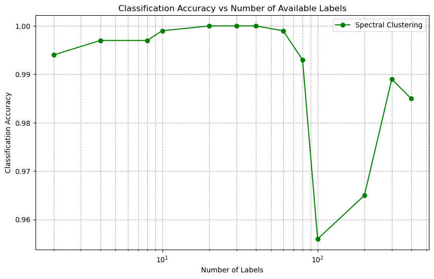

```python
plt.figure(figsize=(10, 6))
plt.plot(v_num_labels, acc_spectral_clustering, label='Spectral Clustering', color='green', marker='o')
plt.xlabel('Number of Labels')
plt.ylabel('Classification Accuracy')
plt.title('Classification Accuracy vs Number of Available Labels')
plt.xscale('log')
plt.grid(True, which="both", ls="--")
plt.legend()
plt.show()
```

The previous plot shows that the classification accuracy is consistently high across different numbers of labels, all above 95%. This shows that spectral clustering is effective at grouping the data points into meaningful clusters that align well with the true class labels.

There is an initial increase in accuracy as the number of labels increases from 2 to around 30. This indicates that as more clusters are formed, they better capture the underlying class structure of the data, leading to more accurate classification when labeling one representative from each cluster.

Initially, increasing the number of clusters allows the spectral clustering algorithm to refine the boundaries between the classes. We actually only have 2 classes, 0 and 1; however, if we start with only 2 clusters, we are essentially hoping for a perfect separation between the classes. However, if there are subtle variations within the digits that could lead to overlap or misclassification, having more than 2 clusters allows the algorithm to capture these nuances. For example, different writing styles or orientations of the digits might lead to intermediate clusters that are not pure in terms of classes but help in better class separation.

After that, the accuracy seems to plateau with slight variability as the number of labels continues to increase. The plateau suggest that beyond a certain point, creating more clusters does not contribute to more accurate classification. This could happen when additional clusters start to over-segment the classes or split clusters that belong to the same class.

There is a noticeable sharp drop in accuracy when the number of labels is 100, followed by a recovery. With the increase in the number of clusters, the probability of selecting a non-representative sample for labeling each cluster increases. If the randomly chosen sample is not central or typical of the cluster, the propagated label might not match the true labels of other samples in the cluster.

After the drop and subsequent recovery, the accuracy seems to stabilize again, though not quite reaching the previous peak. This stabilization suggests that with even more clusters, the method again starts to find a representative structure that approximates the true classes. However, the fact that it does not reach earlier highs in accuracy might indicate that there are diminishing returns to adding more clusters beyond a certain point. As the number of clusters becomes very high, noise and outliers are increasingly likely to form their own clusters. This segregation can inadvertently correct some of the misclassification that occurred due to over-segmentation, leading to a rise in overall accuracy.

In conclusion, these results seem to support the idea that using spectral clustering with a very limited labeling budget can still result in high classification accuracy. However, there is a level of complexity or a "sweet spot" in terms of the number of clusters where the accuracy is maximized before it becomes counterproductive to add more clusters. The drop and recovery in the plot underscore the importance of choosing the right number of clusters for spectral clustering to be effective, as well as the risks associated with the strategy of labeling only one data point per cluster.

Explore the dependence of the classification accuracy of the spectral clustering with the values of `gamma`.

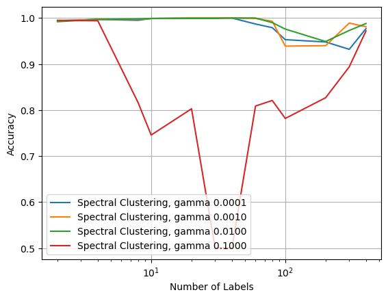

```python
v_num_labels = np.array([2,4,8,10,20,30,40,60,80,100,200,300,400])
v_gamma = [1e-4, 1e-3, 1e-2, 1e-1]
acc_spectral_clustering = np.empty((len(v_gamma), len(v_num_labels)))

for ig, gamma in enumerate(v_gamma):
    for ii, n_clusters in enumerate(v_num_labels):
        predictions = my_spectral_clustering(X, my_oracle, n_clusters=n_clusters, gamma=gamma)
        acc_spectral_clustering[ig, ii] = accuracy_score(Y, predictions)

# Now plot the results
plt.figure()
for ig, gamma in enumerate(v_gamma):
    plt.plot(v_num_labels, acc_spectral_clustering[ig, :], label=f'Spectral Clustering, gamma {gamma:.4f}')
plt.legend()
plt.xlabel('Number of Labels')
plt.ylabel('Accuracy')
plt.xscale('log')
plt.grid()
plt.show()
```

The parameter gamma in spectral clustering controls the width of the neighborhood in the similarity graph constructed by the RBF kernel. A high gamma value leads to a graph where only the nearest neighbors are strongly connected. On the contrary, a low gamma value creates a smoother graph where distant points can influence each other, potentially leading to fewer, larger clusters.

Interpretation of Each Gamma Line:

**Gamma = 0.1 (Red Line)**: The high gamma value results in significant variability in classification accuracy. This suggests that the algorithm is sensitive to the local structure of the data, perhaps too much so. At this scale, the algorithm may create clusters that are too fine, potentially dividing what should be cohesive classes into multiple clusters. This results in the severe drops in accuracy seen, especially when the number of labels is moderate to high. The high gamma value may be capturing noise as structure, which is detrimental to the classification performance.

**Gamma = 0.01 (Green Line)**: A tenfold decrease in gamma produces a more stable accuracy, though with some fluctuations. This intermediate gamma value seems to be less sensitive to noise and more capable of capturing the true underlying structure of the data. However, it still exhibits some variability, which suggests that while it is much better than a gamma of 0.1, it might still be creating clusters that do not perfectly align with the actual class divisions.

**Gamma = 0.001 (Orange Line)**: The orange line represents a gamma that appears to balance well between the global and local structures, offering good performance across a range of label numbers. At this scale, the similarity graph is likely reflecting a more accurate global structure without being overly disrupted by local noise. This gamma value seems to allow the algorithm to separate the classes effectively while also being robust to the number of clusters specified.

**Gamma = 0.0001 (Blue Line)**: The blue line, which corresponds to the lowest gamma, shows one of the highest and most consistent accuracy. This suggests that the broader kernel width, which allows for distant points to influence each other, is beneficial for this dataset. It may indicate that the true class structure in the data is relatively simple or that the classes are separated by wide margins. A broader neighborhood helps in clearly defining class boundaries without being misled by within-class variability or noise.

With a high gamma, the similarity graph becomes more local. Only points that are very close to each other are considered similar, leading to a graph with many small neighborhoods. When we ask the spectral clustering algorithm to find clusters in this graph, it tends to create more, smaller clusters. However, if we specify fewer clusters than the graph's inherent local structure suggests, the algorithm may force together points that are not truly similar, leading to poor performance. On the other hand, a low gamma value creates a similarity graph where even distant points can be considered part of the same neighborhood. The algorithm sees a "bigger picture" of the data. In this case, if the similarity graph suggests fewer, larger clusters and we specify too many, we may end up splitting cohesive groups unnecessarily, again degrading performance. The best performance is typically achieved when the number of clusters we specify matches the true number of distinct groups in the data, as represented by the similarity graph constructed with an appropriate gamma value.

Choose one of the values of `gamma` explaining the reasons behind this selection. Plot the evolution (as the number of clusters varies) of the accuracy of the Spectral Clustering with that value of `gamma` and compare these results with those obtained with the SVM for the same number of labels. Including the curves of spectral clustering and SVM in the same figure can help organize the discussion.

[figure not shown]

```python
mean_acc_svm = np.mean(acc_svm_random_label, axis=0)
gamma_index = 1
gamma= 0.001
# Plot the results
plt.figure(figsize=(10, 6))

# SVM plot with error region
plt.plot(v_num_labels, mean_acc_svm, label='SVM (mean accuracy)', color='blue',marker='o' )

# Spectral Clustering plot for gamma = 0.0001
plt.plot(v_num_labels, acc_spectral_clustering[gamma_index, :], label=f'Spectral Clustering, gamma {gamma}', color='red', marker='o')

plt.xlabel('Number of Labels')
plt.ylabel('Classification Accuracy')
plt.title('Comparison of Spectral Clustering and SVM Accuracy')
plt.xscale('log')
plt.legend()
plt.grid(True, which="both", ls="--")
plt.show()
```

```python
mean_acc_svm = np.mean(acc_svm_random_label, axis=0)
binary_mean_acc_svm=mean_acc_svm
binary_spectral_clustering= acc_spectral_clustering[1, :]
```

```python
binary_mean_acc_svm.shape
```

```
(13,)
```

The SVM starts with lower accuracy when only a few labels are available. This makes sense as SVMs are supervised learning models that typically require a higher number of labeled examples to define the optimal separating hyperplane. The accuracy sharply increases as the number of labels grows from very few to a moderate amount. This is consistent with the SVM's need for more data to accurately capture the decision boundary between classes. However, as more labels are added, the improvement in accuracy plateaus. This is typical in learning curves, where the initial data points contribute significantly to model performance, but each additional point contributes less to accuracy improvements as the model approaches its performance limit.

On the other hand, spectral clustering begins with a high accuracy, even at a low number of clusters. In this case, the accuracy remains relatively stable as the number of clusters increases. The chosen gamma value of 0.001 seems to be well-tuned to the data's scale, maintaining good performance across different levels of granularity. As mentioned before, there are some minor fluctuations in accuracy, but these are relatively small. This indicates that the spectral clustering is robust to the number of clusters specified, likely because the clusters it forms correspond well to the true structure of the data.

In the initial phase with very few labels, spectral clustering outperforms SVM. This is expected since, unlike SVM, which requires labeled examples to learn the decision boundary, spectral clustering does not depend on labels for its initial grouping process. It only requires a handful of labels to assign a label to each cluster. Therefore, it can achieve high accuracy even if only a few instances have labels, as long as the clustering step correctly identifies the underlying structure of the data.

The spectral clustering line's relative flatness at gamma = 0.001 demonstrates a good match between the chosen gamma and the inherent data structure. It manages to maintain high accuracy regardless of cluster count, which could indicate that the main classes are separated enough that even when subdivided into more clusters, the additional granularity does not confuse the classifier. Alternatively, as the number of labels increases, SVM's accuracy improves and becomes competitive with spectral clustering. This shows that with sufficient data, SVM can be a robust classifier, often reaching an accuracy comparable to that of spectral clustering.

Spectral clustering is particularly advantageous when labels are scarce. It leverages the geometry of the data space to uncover structure without needing class labels for every instance. However, the SVM catches up in performance as more labeled data becomes available, indicating that with enough information, it effectively captures the data's underlying patterns. These outcomes suggest that spectral clustering is an effective strategy for this dataset if the labels are limited. However, as more labels become available, SVM becomes equally viable.

# 3.- Binary problem even vs odd

Repeat the analysis with the data included in the files "x_all_even_odd.csv" and "y_all_even_odd.csv". Discuss the separability of the classes in this problem with respect to the separability of the 0 vs. 1 case.

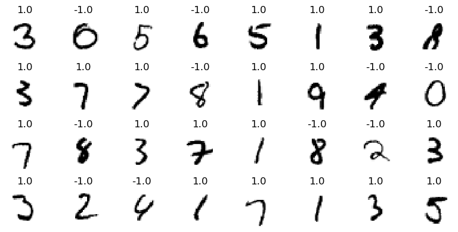

```python
Y = np.loadtxt("y_all_even_odd.csv",
                       delimiter=",")
X=np.loadtxt("x_all_even_odd.csv",
                       delimiter=",")

nrows = 4
ncols = 8
ff,aa = plt.subplots(nrows, ncols,figsize=(8,4))
ii = 0
for rr in range(nrows):
    for cc in range(ncols):
        aa[rr][cc].set_axis_off()
        aa[rr][cc].imshow(X[ii].reshape(28,28),
                          cmap=plt.cm.gray_r,
                          interpolation='nearest')
        aa[rr][cc].set_title(repr(Y[ii]))
        ii += 1
ff.tight_layout()
```

# 3.1 SVM

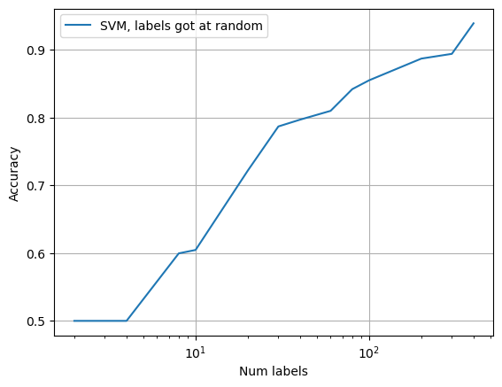

```python
# Load data
Y = pd.read_csv("y_all_even_odd.csv").to_numpy().ravel()
X = pd.read_csv("x_all_even_odd.csv").to_numpy()

# Define parameters
C = 100
gamma = 0.001

# Define the number of labelled samples
v_num_labels = np.array([2, 4, 8, 10, 20, 30, 40, 60, 80, 100, 200, 300, 400])

# Initialize array to store accuracy values
acc_svm_random_label = np.empty(len(v_num_labels))

# Loop through different numbers of labelled samples
for nn, num_data in enumerate(v_num_labels):
    # Randomly select num_data training examples
    idx = np.random.choice(len(X), size=num_data, replace=False)
    X_train = X[idx]
    Y_train = Y[idx]

    # Check if both classes are present in the sampled data
    unique_classes = np.unique(Y_train)
    if len(unique_classes) < 2:
        acc_svm_random_label[nn] = 0.5  # Set accuracy to 0.5 for random guessing
    else:
        # Train SVM with the selected training examples
        clf = svm.SVC(kernel='rbf', C=C, gamma=gamma)
        clf.fit(X_train, Y_train)

        # Evaluate the SVM using the entire dataset
        accuracy = clf.score(X, Y)
        acc_svm_random_label[nn] = accuracy

# Plot accuracy vs number of labels
plt.figure()
plt.plot(v_num_labels, acc_svm_random_label, label='SVM, labels got at random')
plt.legend()
plt.xlabel('Num labels')
plt.ylabel('Accuracy')
plt.xscale('log')
plt.grid()
plt.show()
```

When the number of labeled examples is smallest, the SVM's accuracy is not much better than random guessing. This suggests that with very few labeled points, the SVM cannot construct a reliable model of the data's underlying structure. As the number of labels increases, there is a sharp, almost linear increase in accuracy. This reflects that each additional labeled example significantly contributes to the SVM's ability to define the decision boundary. Given the more complex nature of the "even vs. odd" classification task compared to the "0 vs. 1" task, the SVM requires a substantial number of examples to capture the nuances necessary to differentiate between the classes. As more labels are provided, the rate of increase in accuracy starts to slow down, and the curve begins to plateau, although it is still on an upward trend at the end of the plot. This behavior is typical of learning curves in machine learning, where the marginal benefit of additional data diminishes as the model becomes more refined. If we were to compare this curve to the one obtained from the "0 vs. 1" classification, we might notice a couple of differences. First, the starting accuracy for the "even vs. odd" task is likely lower, reflecting the increased complexity of distinguishing between multiple pairs of digits as opposed to just two. Second, the rate at which accuracy increases with additional labels might be less steep in the "even vs. odd" case, again due to the task's greater complexity. Despite the more challenging classification task, the plot suggests that given a sufficient number of labeled examples, the SVM can still achieve a high level of accuracy. This indicates that even for more complex separations, such as distinguishing even from odd numbers, the SVM can be a powerful classifier when provided with enough data. The fact that the accuracy continues to increase (and does not fully plateau within the observed range of labels) implies that the SVM has not yet reached its performance limit. More labeled data could potentially lead to even higher accuracy.

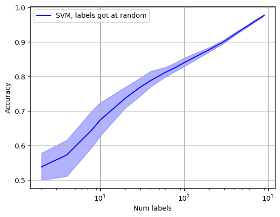

```python
v_num_labels = np.array([2,4,8,10,20,30,40,60,80,100,200,300,400,500,600,700,800,900])
NSIM = 100
acc_svm_random_label = np.empty((NSIM, len(v_num_labels)))  # each row is for each of the NSIM simulations

# Loop through different simulations
for sim in range(NSIM):
    # Loop through different numbers of labelled samples
    for nn, num_data in enumerate(v_num_labels):
        # Randomly select num_data training examples
        idx = np.random.choice(len(X), size=num_data, replace=False)
        X_train = X[idx]
        Y_train = Y[idx]

        # Check if both classes are present in the sampled data
        unique_classes = np.unique(Y_train)
        if len(unique_classes) < 2:
            acc_svm_random_label[sim, nn] = 0.5  # Set accuracy to 0.5 for random guessing
        else:
            # Train SVM with the selected training examples
            clf = svm.SVC(kernel='rbf', C=C, gamma=gamma)
            clf.fit(X_train, Y_train)

            # Evaluate the SVM using the entire dataset
            accuracy = clf.score(X, Y)
            acc_svm_random_label[sim, nn] = accuracy

# Plot mean and standard deviation of accuracy
plt.figure()
plt.plot(v_num_labels, np.mean(acc_svm_random_label, axis=0), label='SVM, labels got at random', color='blue')
plt.fill_between(v_num_labels, np.percentile(acc_svm_random_label, 25, axis=0),
                 np.percentile(acc_svm_random_label, 75, axis=0),
                 color='blue', alpha=0.3)
plt.legend()
plt.xlabel('Num labels')
plt.ylabel('Accuracy')
plt.xscale('log')
plt.grid()
plt.show()
```

The plot above shows the mean accuracy of the SVM classifier as a function of the number of labeled examples used for training, with the shaded area representing the range between the 25th and 75th percentiles.

The graph starts with an accuracy close to random chance when very few labels are used, indicating that with insufficient labeled data, the SVM cannot reliably differentiate between the even and odd classes. As the number of labels increases, the accuracy improves significantly, demonstrating that the SVM can better model the decision boundary between the classes with more information.

As mentioned before, the curve's ascent starts to taper as it approaches the higher number of labels. However, the accuracy has not plateaued within the observed range, implying that more labels could still enhance the model's performance.

The shaded region, which represents variability in accuracy across simulations, narrows as the number of labels increases. This reduction in variability shows that with more data, the SVM's performance becomes more consistent and less dependent on the specific samples selected for training.

In juxtaposition with the "0 vs. 1" classification scenario, the "even vs. odd" task exhibits a somewhat lower starting accuracy, showing that distinguishing between these broader categories is inherently more challenging. Despite this initial lower accuracy, the confidence interval is narrower, which points to a more consistent performance across different simulations as the number of labels increases. The curve rises less sharply, signaling that achieving high accuracy for the even-odd classification demands a larger set of labeled examples compared to the more straightforward "0 vs. 1" task. Moreover, while the "0 vs. 1" case achieves a relatively tight confidence interval with as few as 10 labels, the even-odd task requires at least 100 labels to reach a comparable level of precision in its predictive consistency. This underlines the complexity of the even-odd classification, as it involves a more intricate decision boundary that necessitates additional data to define with a similar degree of certainty.

# 3.2 SPECTRAL CLUSTER

```python
from sklearn.cluster import SpectralClustering
import numpy as np
from sklearn.neighbors import KNeighborsClassifier

class oracle(object):
    """
    Simulates an oracle that provides labels for input observations.
    """
    def __init__(self, x, y):
        self.dim = x.shape[1]
        self.knn = KNeighborsClassifier(n_neighbors=1).fit(x, y)

    def get_label(self, x):
        return self.knn.predict(x.reshape(-1, self.dim))

def my_spectral_clustering(x, my_oracle, n_clusters=2, gamma=1):
    """
    Implements classification scheme using Spectral Clustering and a very limited number of labels.
    """
    Nt = x.shape[0]
    # Fit Spectral Clustering
    spectral = SpectralClustering(n_clusters=n_clusters, affinity='rbf', gamma=gamma, assign_labels='kmeans', random_state=0)
    cluster_labels = spectral.fit_predict(x)

    predictions = np.empty(Nt) # Array to fill with the predicted class for all instances in x

    for cc in range(n_clusters):
        # Get the instances that are in cluster cc
        indices = np.where(cluster_labels == cc)[0]
        if len(indices) > 0:
            # Pick one of these instances at random and call it my_x
            random_index = np.random.choice(indices)
            my_x = x[random_index]

            # Get the label for my_x from the oracle
            y_cluster = my_oracle.get_label(my_x)

            # Fill the positions of the instances in cluster cc in the array predictions with y_cluster
            predictions[indices] = y_cluster

    return predictions
```

```python
v_num_labels = np.array([2,4,8,10,20,30,40,60,80,100,200,300,400]) # number of labelled samples
acc_spectral_clustering = np.empty(len(v_num_labels))
gamma = 0.001
my_oracle = oracle(X,Y)
for ii,n_clusters in enumerate(v_num_labels):
    predictions = my_spectral_clustering(X, my_oracle, n_clusters=n_clusters, gamma=gamma)
    acc_spectral_clustering[ii] = np.mean(predictions == Y)
```

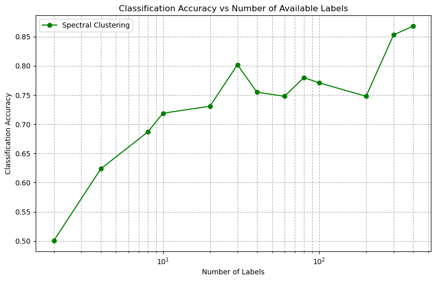

```python
plt.figure(figsize=(10, 6))
plt.plot(v_num_labels, acc_spectral_clustering, label='Spectral Clustering', color='green', marker='o')
plt.xlabel('Number of Labels')
plt.ylabel('Classification Accuracy')
plt.title('Classification Accuracy vs Number of Available Labels')
plt.xscale('log')
plt.grid(True, which="both", ls="--")
plt.legend()
plt.show()
```

Starting from a low accuracy that is just above random chance with very few labels, the accuracy climbs as more labels are provided, this can be explained by the fact that ff the data has inherent groupings that are more granular than just "even" versus "odd," initially increasing the number of clusters can help the algorithm to capture these subtleties. For instance, within the "even" numbers, digits like "0" and "8" might have similar pixel patterns that are distinct from "2" and "4", so more clusters can initially help to distinguish between these sub-groups better.

However, the plot also exhibits fluctuations, with peaks and valleys in accuracy as the number of clusters continues to increase. This "wiggly" behavior likely reflects the variability inherent in the process of assigning labels to clusters based on a single representative. Depending on which instances are selected as representatives, the labeling could be more or less representative of their respective clusters.

Despite the variability, the general trend suggests an improvement in accuracy with more clusters. This improvement implies that the additional clusters are beneficial in capturing the data's structure more accurately. Nevertheless, there is a notable increase in accuracy at the highest cluster counts, suggesting that the algorithm finds a more accurate clustering of the data that aligns well with the even-odd classes as it is provided with more clusters to work with. When we specify more clusters than there are true categories, the spectral clustering algorithm will still find a way to divide the data into the specified number of clusters. If by chance these additional clusters align well with some of the natural variations within the "even" and "odd" classes, then labeling a representative from each cluster can lead to more accurate classification, as subtle distinctions within the classes are being accounted for.

Now we will add more labels to see if the acuuracy plateaus.

```python
#for this part i will try adding more labels to see if the accuracy stabilizes

v_num_labels = np.array([2,4,8,10,20,30,40,60,80,100,200,300,400,500,600,700,800,900]) # number of labelled samples
acc_spectral_clustering = np.empty(len(v_num_labels))
gamma = 0.001
my_oracle = oracle(X,Y)
for ii,n_clusters in enumerate(v_num_labels):
    predictions = my_spectral_clustering(X, my_oracle, n_clusters=n_clusters, gamma=gamma)
    acc_spectral_clustering[ii] = np.mean(predictions == Y)
```

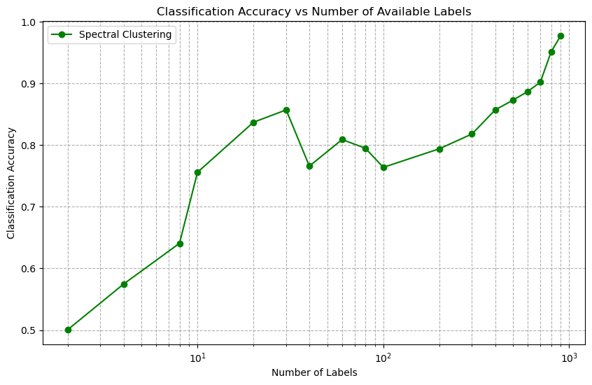

```python
plt.figure(figsize=(10, 6))
plt.plot(v_num_labels, acc_spectral_clustering, label='Spectral Clustering', color='green', marker='o')
plt.xlabel('Number of Labels')
plt.ylabel('Classification Accuracy')
plt.title('Classification Accuracy vs Number of Available Labels')
plt.xscale('log')
plt.grid(True, which="both", ls="--")
plt.legend()
plt.show()
```

In the context of the MNIST dataset, the digits are represented as 28x28 pixel images, leading to a high-dimensional space where even and odd numbers form distinct but complex groupings. The initial rise in accuracy with more clusters suggests that a greater number of clusters allows spectral clustering to more finely partition this space and detect the nuanced differences between even and odd digits, which might be lost with too few clusters.

As the number of clusters continues to increase, the spectral clustering algorithm becomes capable of capturing the subtleties within those categories. For example, as mentioned before, within the evens, '0' and '8' are more rounded, while '2' and '4' have sharper angles and lines. By providing more clusters, we allow the algorithm to potentially allocate separate clusters for these sub-patterns, enhancing the accuracy of the even-odd classification.

The accuracy increase indicates that, at least for this dataset, the inherent separability between even and odd digits is substantial and that spectral clustering can exploit this separability more effectively as it is allowed to use more clusters. However, it is also crucial to be mindful of the computational cost and the risk of overfitting.

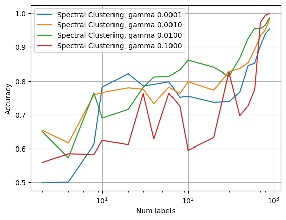

```python
# Initialize the oracle with the actual dataset
my_oracle = oracle(X, Y)

v_gamma = [1e-4, 1e-3, 1e-2, 1e-1]  # Gamma values to explore
v_num_labels = np.array([2,4,8,10,20,30,40,60,80,100,200,300,400,500,600,700,800,900])
#v_num_labels = np.array([2, 4, 8, 10, 20, 30, 40, 60, 80, 100, 200, 300, 400, 500, 600,900])  # Number of clusters/labels

acc_spectral_clustering = np.empty((len(v_gamma), len(v_num_labels)))  # Storage for accuracies

for ig, gamma in enumerate(v_gamma):
    for ii, n_clusters in enumerate(v_num_labels):
        predictions = my_spectral_clustering(X, my_oracle, n_clusters=n_clusters, gamma=gamma)
        acc_spectral_clustering[ig, ii] = accuracy_score(Y, predictions)

# Plotting
plt.figure()
for ig, gamma in enumerate(v_gamma):
    plt.plot(v_num_labels, acc_spectral_clustering[ig, :], label=f'Spectral Clustering, gamma {gamma:.4f}')
plt.legend()
plt.xlabel('Num labels')
plt.ylabel('Accuracy')
plt.xscale('log')
plt.grid()
plt.show()
```

From the plot above we can study the accuracy of spectral clustering with varying gamma values and numbers of clusters. The graph reveals several key aspects of how gamma and the number of clusters interact to influence classification accuracy:

**Low Gamma (blue line, 0.0001)**: With the lowest gamma value, the similarity graph generated by spectral clustering emphasizes global structure over local nuances. At this setting, even when few clusters are defined, the algorithm may group the digits into broader categories, potentially combining various even or odd digits into single clusters. As the number of clusters increases, the accuracy tends to rise, indicating that additional granularity helps to refine the classification. However, the accuracy does not climb as steeply or as consistently as with higher gamma values, which suggests that while the global structure is recognized, the finer distinctions necessary for higher accuracy are not captured as effectively.

**Intermediate Gamma (orange and green lines, 0.001 and 0.01)**: These gamma values offer a balance between sensitivity to local details and the broader structure of the data. The accuracy initially improves more rapidly with the number of clusters compared to the lowest gamma setting, suggesting that these gamma values are better suited to capturing the intricacies within the MNIST digits. The fluctuations in accuracy might reflect the algorithm's attempt to reconcile local differences within the even and odd categories as more clusters are added. The intermediate gamma values seem to allow for meaningful clustering that can adjust as more detailed separations are needed.

**High Gamma (red line, 0.1)**: The highest gamma value places a strong emphasis on local similarities, which might be too restrictive when few clusters are used. This setting could cause the algorithm to create clusters that are too finely tuned to small subsets of the data, possibly leading to overfitting. As more clusters are introduced, the accuracy improves significantly, potentially because the high gamma allows the algorithm to separate distinct digits into their own clusters effectively. However, the considerable variability in accuracy at higher numbers of clusters suggests that the clusters may be inconsistently capturing the underlying patterns, possibly splitting individual digits into multiple clusters.

The optimal combination of gamma and the number of clusters depends on the inherent structure of the data. For the MNIST dataset, which contains complex patterns within both even and odd digit categories, an intermediate gamma seems to provide a good balance between capturing global structures and attending to local details. The accuracy's increase with the number of clusters across all gamma values suggests that there is a level of complexity in the dataset that is better addressed when the algorithm has more flexibility to form clusters. However, there is a sweet spot where the number of clusters and the value of gamma intersect to provide the highest accuracy, indicating the best representation of the data's true structure.

For this reasons the gamma 0.01 will be select4ed for the following comparisons.

[figure not shown]

```python
mean_acc_svm = np.mean(acc_svm_random_label, axis=0)
gamma_index = 2
gamma= 0.01
# Plot the results
plt.figure(figsize=(10, 6))
v_num_labels = np.array([2,4,8,10,20,30,40,60,80,100,200,300,400,500,600,700,800,900])
# SVM plot with error region
plt.plot(v_num_labels, mean_acc_svm, label='SVM (mean accuracy)', color='blue',marker='o' )

# Spectral Clustering plot for gamma = 0.0001
plt.plot(v_num_labels, acc_spectral_clustering[gamma_index, :], label=f'Spectral Clustering, gamma {gamma}', color='red', marker='o')

plt.xlabel('Number of Labels')
plt.ylabel('Classification Accuracy')
plt.title('Comparison of Spectral Clustering and SVM Accuracy')
plt.xscale('log')
plt.legend()
plt.grid(True, which="both", ls="--")
plt.show()
```

```python
mean_acc_svm = np.mean(acc_svm_random_label, axis=0)
bo_spectral_clustering=acc_spectral_clustering[2, :]
bo_mean_acc_svm=mean_acc_svm
```

```python
bo_spectral_clustering.shape
```

```
(18,)
```

We have commented separately on the results obtained from SVM and spectral clustering. However, we will use this plot to make a final comparison between the 2 methods.

The SVM (blue line) shows a general upward trend in accuracy as the number of labels increases, which is expected in supervised learning. More labeled examples provide more information about the decision boundary between even and odd numbers, allowing the SVM to construct a more accurate model. The performance improvement appears to be relatively smooth and consistent, which is typical for SVMs given their deterministic nature.

When comparing the two algorithms, it is noticeable that SVM maintains a consistent performance increase and surpasses spectral clustering in terms of accuracy, especially beyond around 100 clusters. This could be due to SVM's robustness and its ability to handle large numbers of examples without the risk of mislabeling that spectral clustering faces. Spectral clustering's performance (red line), especially at a gamma of 0.01, shows it is sensitive to the number of clusters. The right amount of clusters allows it to capture the data's structure effectively, but too many can introduce noise, and too few can fail to capture necessary detail. The choice of gamma = 0.01 for spectral clustering indicates a moderate emphasis on local connectivity, which seems to be beneficial for the MNIST dataset. This gamma value likely provides a balance between considering local pixel patterns and overall digit structure.

# 4.- Final discussion

Put all the results in a same plot and discuss the ranges of number of available labels for which each classification method seems more convenient. Include in the discussion the influence of the separability of the problem.

```python
bo_mean_acc_svm = bo_mean_acc_svm[0:13]
bo_spectral_clustering = bo_spectral_clustering[0:13]
```

```python
binary_spectral_clustering.shape
binary_mean_acc_svm.shape
```

```
(13,)
```

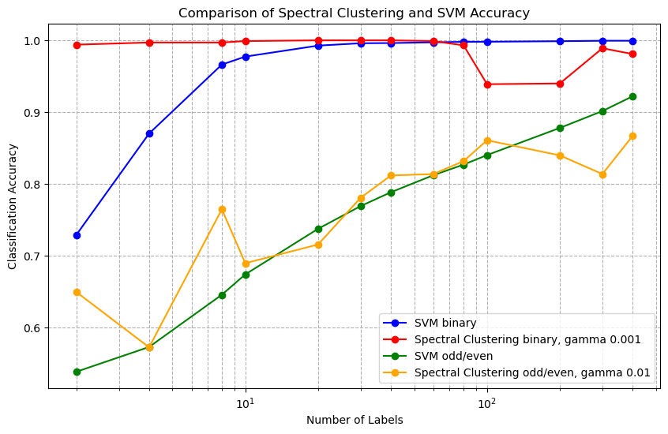

```python
plt.figure(figsize=(10, 6))
v_num_labels = np.array([2,4,8,10,20,30,40,60,80,100,200,300,400])
# SVM plot with error region
plt.plot(v_num_labels, binary_mean_acc_svm, label='SVM binary', color='blue',marker='o' )

# Spectral Clustering plot for gamma = 0.0001
plt.plot(v_num_labels, binary_spectral_clustering, label=f'Spectral Clustering binary, gamma {0.001}', color='red', marker='o')
plt.plot(v_num_labels, bo_mean_acc_svm, label='SVM odd/even', color='green',marker='o' )
plt.plot(v_num_labels, bo_spectral_clustering, label=f'Spectral Clustering odd/even, gamma {0.01}', color='orange', marker='o')

plt.xlabel('Number of Labels')
plt.ylabel('Classification Accuracy')
plt.title('Comparison of Spectral Clustering and SVM Accuracy')
plt.xscale('log')
plt.legend()
plt.grid(True, which="both", ls="--")
plt.show()
```

In this plot, we show a comparison of the classification accuracies for SVM and spectral clustering across two classification tasks on the MNIST dataset: distinguishing between '0' and '1' digits and discerning odd from even numbers. The accuracies are plotted against an increasing number of labels, which, for the purposes of spectral clustering, correspond to the number of clusters.

In the task of differentiating '0' and '1', the SVM model demonstrates a high level of accuracy with relatively few labels. This suggests that the features separating these two digits are quite distinct and can be easily learned by the SVM. On the other hand, the odd/even classification proves to be more challenging, as evidenced by the lower accuracy of the SVM at the start, which then improves gradually with an increasing label count. The task's complexity lies in the higher intra-class variability, necessitating more labeled examples for the SVM to accurately establish a decision boundary.

Spectral clustering for the binary classification shows an impressive performance that quickly reaches a high accuracy plateau. The gamma setting of 0.001 appears to be particularly well-suited for this task, enabling the algorithm to effectively capitalize on the clear structural differences between '0' and '1'. Conversely, for the odd/even task, spectral clustering starts with lower accuracy. However, as the number of clusters rises, so does the accuracy, especially with gamma set to 0.01. This higher gamma value emphasizes the local connections within the data, allowing for a finer granularity in distinguishing the subtler variations among the different digits, ultimately leading to a more nuanced and accurate classification.

Looking at the plot, the trends suggest that at low to moderate numbers of labels, spectral clustering may offer a more advantageous approach for tasks where the classes are highly separable. This is particularly notable in the binary task, where fewer clusters are needed to achieve high performance due to the clear separation between '0' and '1'. In contrast, the SVM's steady improvement as the number of labels increases reflects its capacity for effectively handling more complex classification tasks given enough labeled data.

The sharp rise in accuracy with more labels for the SVM in the odd/even task and the continued improvement in spectral clustering's performance with increased clusters underscores the impact of class separability on model performance. Where classes are less distinct, as with the odd/even task, more sophisticated modeling and an increased label budget are required.

In conclusion, while both models show improved performance with more data, the choice between SVM and spectral clustering should be informed by the nature of the classification task at hand, the separability of the classes involved, and the availability of labeled data. For straightforward tasks with distinct class boundaries, spectral clustering can be especially effective with fewer labels. Meanwhile, SVM stands out for its ability to handle more complex tasks, provided it is supplied with a sufficient amount of labeled data to learn the underlying patterns within the data.

# Extra

Check what happens if you train the SVMs with the labelled samples that the spectral clustering uses to label each cluster instead of with the randomly selected labels.

## 0/1 clasiffication

For this extra section, we have decided to run some of the previous code again to easily run only the this section without needing to look for the specific cell to run in the main assignment code.

```python
from sklearn import svm
from sklearn.cluster import SpectralClustering
from sklearn.neighbors import KNeighborsClassifier
import numpy as np
import pandas as pd
import matplotlib.pyplot as plt
```

```python
class oracle(object):
    """
    Simulates an oracle that provides labels for input observations.
    """
    def __init__(self, x, y):
        self.dim = x.shape[1]
        self.knn = KNeighborsClassifier(n_neighbors=1).fit(x, y)

    def get_label(self, x):
        return self.knn.predict(x.reshape(-1, self.dim))
```

```python
# Load data
Y_01 = np.loadtxt("y_01.csv",
                       delimiter=",")
X_01 = np.loadtxt("x_01.csv",
                       delimiter=",")
```

```python
NSIM = 100
acc_svm_random_label = np.empty((NSIM, len(v_num_labels)))  # each row is for each of the NSIM simulations
v_num_labels = np.array([2,4,8,10,20,30,40,60,80,100,200,300,400])
# Loop through different simulations
for sim in range(NSIM):
    # Loop through different numbers of labelled samples (same loop as before)
    for nn, num_data in enumerate(v_num_labels):
        # Randomly select num_data training examples
        idx = np.random.choice(len(X_01), size=num_data, replace=False)
        X_train = X_01[idx]
        Y_train = Y_01[idx]

        # Check if both classes are present in the sampled data
        unique_classes = np.unique(Y_train)
        if len(unique_classes) < 2:
            acc_svm_random_label[sim, nn] = 0.5  # Set accuracy to 0.5 for random guessing
        else:
            # Train SVM with the selected training examples
            clf = svm.SVC(kernel='rbf', C=C, gamma=gamma)
            clf.fit(X_train, Y_train)

            # Evaluate the SVM using the entire dataset
            accuracy = clf.score(X_01, Y_01)
            acc_svm_random_label[sim, nn] = accuracy
```

```python
mean_acc_svm = np.mean(acc_svm_random_label, axis=0)
binary_mean_acc_svm=mean_acc_svm
```

```python
# Initialize the oracle
my_oracle = oracle(X_01, Y_01)

# SVM Parameters
C = 100
gamma = 0.001

# Initialize array to store accuracy values for SVM trained on spectral clustering labels
acc_svm_spectral_label = np.empty(len(v_num_labels))

# Loop through the number of labels
for nn, n_clusters in enumerate(v_num_labels):
    # spectral clustering
    spectral = SpectralClustering(n_clusters=n_clusters, affinity='rbf', gamma=gamma, assign_labels='kmeans', random_state=0)
    cluster_labels = spectral.fit_predict(X_01)

    # Arrays to store training data for SVM
    X_train = np.empty((n_clusters, X_01.shape[1]))
    Y_train = np.empty(n_clusters)

    # Select one sample per cluster to train the SVM
    for cc in range(n_clusters):
        indices = np.where(cluster_labels == cc)[0]
        if len(indices) > 0:
            random_index = np.random.choice(indices)
            X_train[cc] = X_01[random_index]
            Y_train[cc] = Y_01[random_index]

    # Train SVM with samples selected by spectral clustering
    clf = svm.SVC(kernel='rbf', C=C, gamma=gamma)
    clf.fit(X_train, Y_train)

    # Evaluate the SVM on the entire dataset
    accuracy = clf.score(X_01, Y_01)
    acc_svm_spectral_label[nn] = accuracy
```

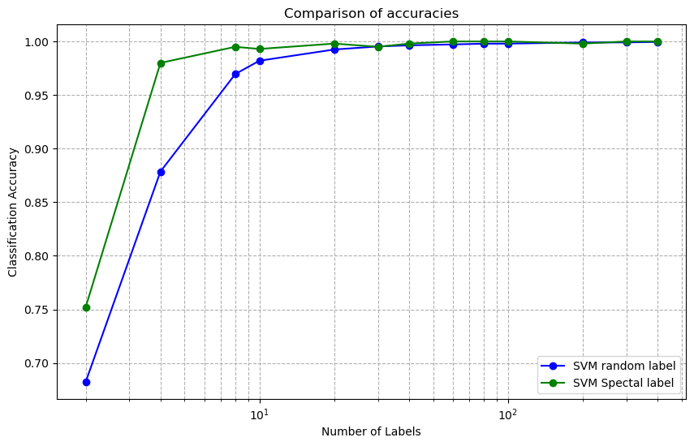

```python
plt.figure(figsize=(10, 6))
v_num_labels = np.array([2,4,8,10,20,30,40,60,80,100,200,300,400])
# SVM plot with error region
plt.plot(v_num_labels, binary_mean_acc_svm, label='SVM random label', color='blue',marker='o' )

# SVM with Spectral Clustering labels
plt.plot(v_num_labels, acc_svm_spectral_label, label='SVM Spectal label', color='green',marker='o' )

plt.xlabel('Number of Labels')
plt.ylabel('Classification Accuracy')
plt.title('Comparison of accuracies')
plt.xscale('log')
plt.legend()
plt.grid(True, which="both", ls="--")
plt.show()
```

The plot above compares the classification accuracy of two SVM models: one trained with labels obtained at random and the other with labels derived from spectral clustering. The key difference between these models lies in the label selection process for training the SVM.

In the case of the SVM trained with randomly selected labels (SVM random label), the labels are chosen without any prior knowledge of the data's structure. This approach may sometimes select less representative samples, which could negatively impact the model's performance, especially when the number of labels (and thus the training samples) is small. However, as the number of randomly selected labels increases, the model's accuracy tends to improve, likely because the chances of including representative samples also increase.

On the other hand, the SVM trained with spectral clustering labels (SVM Spectral label) uses the spectral clustering algorithm to identify clusters within the data. A representative sample from each cluster is then labeled by the oracle and used to train the SVM. This method makes use of the underlying structure of the data, with the assumption that each cluster corresponds to a single class. Therefore, even with a small number of labels, this model can achieve high accuracy since the samples used to train the SVM are more likely to be representative of their respective classes.

From the plot, it is evident that the SVM Spectral label outperforms the SVM random label across nearly all numbers of labels. This result suggests that utilizing the structural information present in the data to guide label selection is more effective than random selection, especially when the number of available labels is limited. This method's effectiveness hinges on the spectral clustering algorithm's ability to form meaningful clusters that align well with the class boundaries.

However, it is important to note that as the number of labels increases, the performance gap between the two methods narrows. This convergence implies that with sufficient labels, random selection can eventually provide a training set that is just as effective as one chosen with the help of spectral clustering.

In conclusion, when labels are scarce, methods that incorporate knowledge of the data's structure to guide label selection can offer significant advantages. But as more labels become available, the benefits of such structured approaches diminish, and simpler methods may suffice to achieve comparable accuracy.

## Odd/Even classification

```python
# Load data
Y = pd.read_csv("y_all_even_odd.csv").to_numpy().ravel()
X = pd.read_csv("x_all_even_odd.csv").to_numpy()
```

```python
v_num_labels = np.array([2,4,8,10,20,30,40,60,80,100,200,300,400])
NSIM = 100
acc_svm_random_label = np.empty((NSIM, len(v_num_labels)))  # each row is for each of the NSIM simulations

# Loop through different simulations
for sim in range(NSIM):
    # Loop through different numbers of labelled samples
    for nn, num_data in enumerate(v_num_labels):
        # Randomly select num_data training examples
        idx = np.random.choice(len(X), size=num_data, replace=False)
        X_train = X[idx]
        Y_train = Y[idx]

        # Check if both classes are present in the sampled data
        unique_classes = np.unique(Y_train)
        if len(unique_classes) < 2:
            acc_svm_random_label[sim, nn] = 0.5  # Set accuracy to 0.5 for random guessing
        else:
            # Train SVM with the selected training examples
            clf = svm.SVC(kernel='rbf', C=C, gamma=gamma)
            clf.fit(X_train, Y_train)

            # Evaluate the SVM using the entire dataset
            accuracy = clf.score(X, Y)
            acc_svm_random_label[sim, nn] = accuracy
```

```python
mean_acc_svm = np.mean(acc_svm_random_label, axis=0)
binary_mean_acc_svm=mean_acc_svm
```

```python
# Initialize the oracle
my_oracle = oracle(X, Y)

# SVM Parameters
C = 100
gamma = 0.001
sc_gamma= 0.01 #spectral clustering gamma that gave best results

# Initialize array to store accuracy values for SVM trained on spectral clustering labels
acc_svm_spectral_label = np.empty(len(v_num_labels))

# Loop through the number of labels
for nn, n_clusters in enumerate(v_num_labels):
    # spectral clustering
    spectral = SpectralClustering(n_clusters=n_clusters, affinity='rbf', gamma=sc_gamma, assign_labels='kmeans', random_state=12)
    cluster_labels = spectral.fit_predict(X)

    # Arrays to store training data for SVM
    X_train = np.empty((n_clusters, X.shape[1]))
    Y_train = np.empty(n_clusters)

    # Select one sample per cluster to train the SVM
    for cc in range(n_clusters):
        indices = np.where(cluster_labels == cc)[0]
        if len(indices) > 0:
            random_index = np.random.choice(indices)
            X_train[cc] = X[random_index]
            Y_train[cc] = Y[random_index]

    # Train SVM with samples selected by spectral clustering
    clf = svm.SVC(kernel='rbf', C=C, gamma=gamma)
    clf.fit(X_train, Y_train)

    # Evaluate the SVM on the entire dataset
    accuracy = clf.score(X, Y)
    acc_svm_spectral_label[nn] = accuracy
```

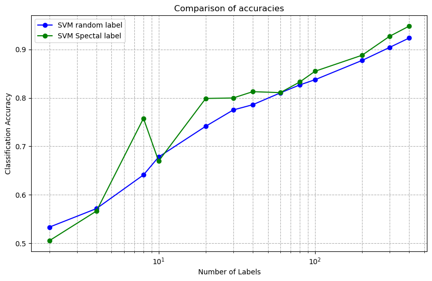

```python
plt.figure(figsize=(10, 6))
v_num_labels = np.array([2,4,8,10,20,30,40,60,80,100,200,300,400])

# SVM plot with error region
plt.plot(v_num_labels, binary_mean_acc_svm, label='SVM random label', color='blue',marker='o' )

# SVM with Spectral Clustering labels
plt.plot(v_num_labels, acc_svm_spectral_label, label='SVM Spectal label', color='green',marker='o' )

plt.xlabel('Number of Labels')
plt.ylabel('Classification Accuracy')
plt.title('Comparison of accuracies')
plt.xscale('log')
plt.legend()
plt.grid(True, which="both", ls="--")
plt.show()
```

In this second case, we observe a comparison between the classification accuracies of the two SVM models on our even/odd digit classification task.